# Experiment 1

### Some info on the models

**Model Original:** q_2 = q_7, q_3 = q_6 & r_3 = r_6 (all but highest confidence response mapping of uncertainty states equated and lowest two confidence response mapping of detection states equated)  
**Q restricted:** q_2 = q_7, q_3 = q_6 (all but highest confidence response mapping of uncertainty states equated)  
**R restricted:** r_3 = r_6 (lowest two confidence response mapping of detection states equated)

### Some info on convergence

#### For Model Original

One approach failed:  
partial, TreeBUGS, beta

Frequentist approach with complete pooling had no convergence problems (asymptotic.complete.MPTinR).

Bayesian approach with no pooling (simple.no.TreeBUGS) had 2 parameters with Rhat > 1.05.  
Bayesian approach with complete pooling (simple.complete.TreeBUGS) converged well, all Rhat < 1.05.  
Bayesian approach with partial pooling (trait.partial.Treebugs) had 3 parameters with Rhat > 1.05 but (trait_uncorrelated.partial.TreeBUGS) converged well, all Rhat < 1.05.

#### For Q restricted

Two approaches failed: partial, TreeBUGS, beta  
partial, TreeBUGS, trait

Bayesian approach with no pooling (simple.no.TreeBUGS) had 2 parameters with Rhat > 1.05.  
Bayesian approach with complete pooling (simple.complete.TreeBUGS) had 14 parameters with Rhat > 1.05.  
Bayesian approach with partial pooling uncorrelated (trait_uncorrelated.partial.TreeBUGS) converged well, all Rhat < 1.05.

#### For R restricted

One approach failed: partial, TreeBUGS, beta

Frequentist approach with complete pooling had no convergence problems (asymptotic.complete.MPTinR).

Bayesian approach with no pooling (simple.no.TreeBUGS) had 44 parameters with Rhat > 1.05.  
Bayesian approach with complete pooling (simple.complete.TreeBUGS) converged well, all Rhat < 1.05.  
Bayesian approach with partial pooling (trait.partial.TreeBUGS) had 33 parameters with Rhat > 1.05 but uncorrelated (trait_uncorrelated.partial.TreeBUGS) had 1 parameter with Rhat > 1.05.

### Parameter estimation

**Model Original**

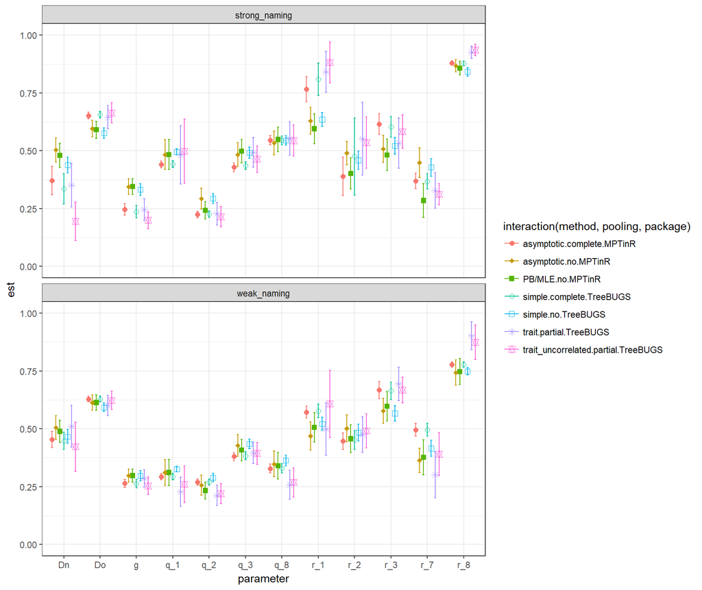

**Q restricted**

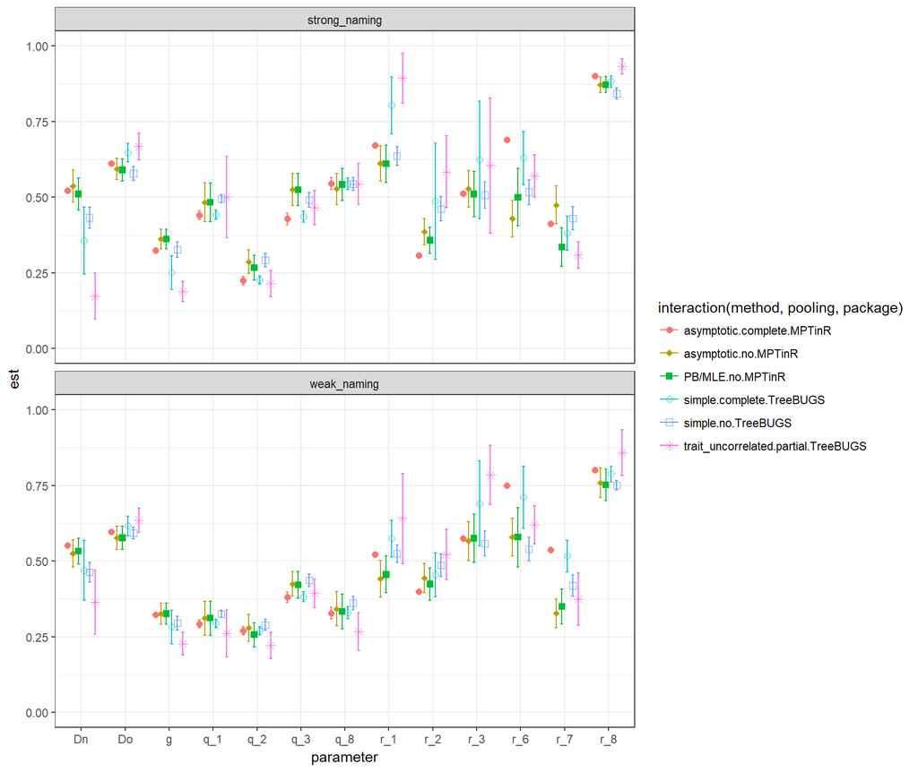

**R restricted**

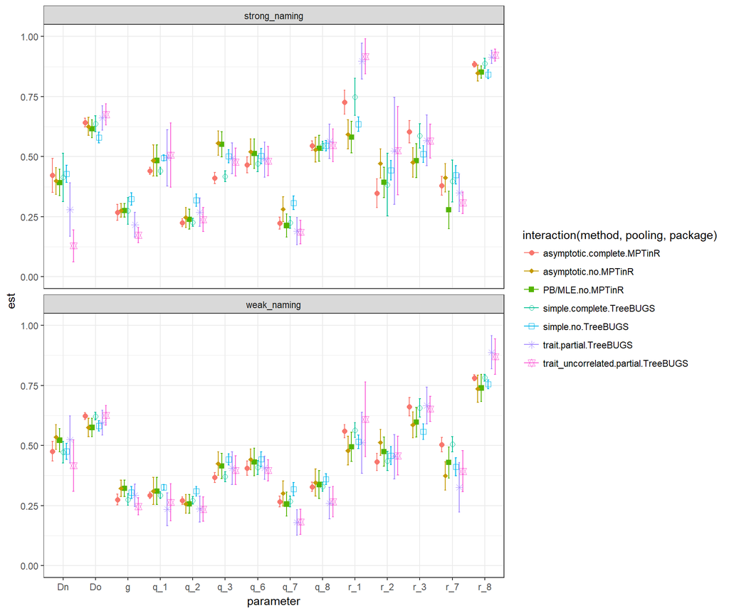

**Core parameters**

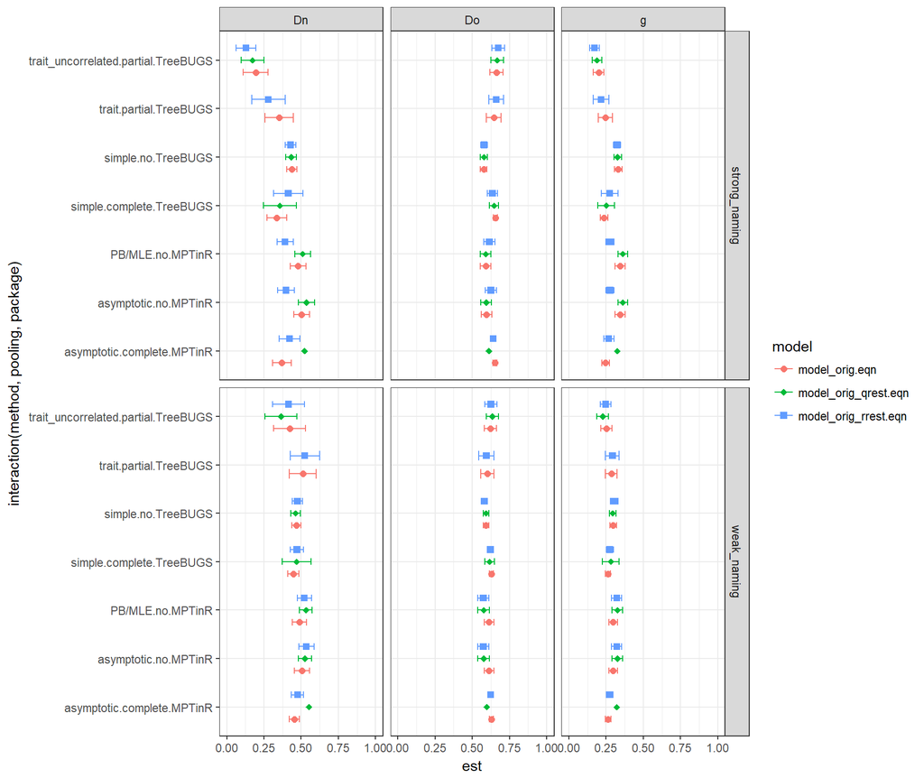

**Q parameters**

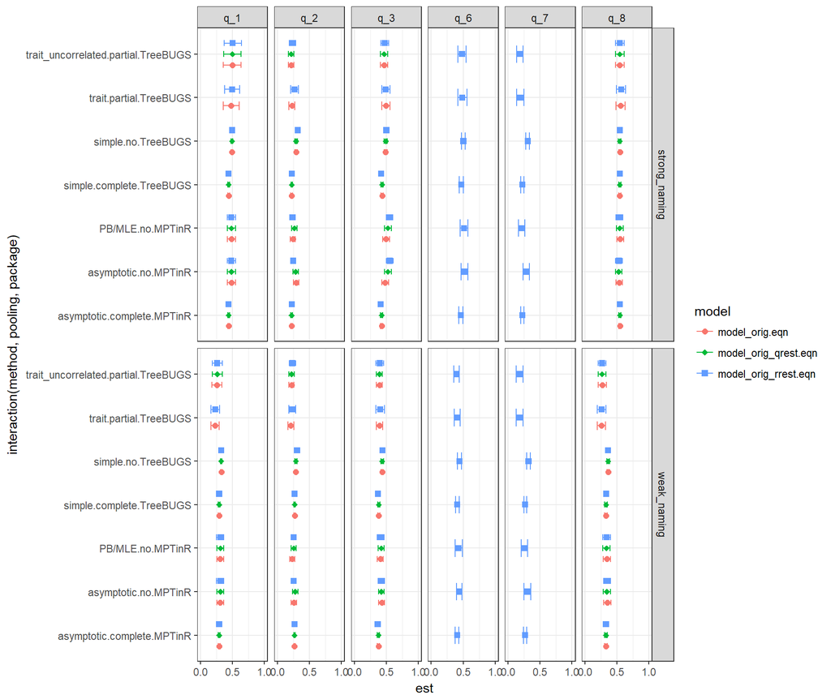

**R parameters**

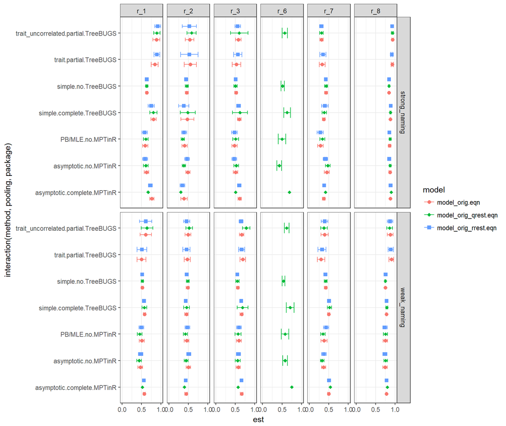

### Estimated differences

**Model Original**

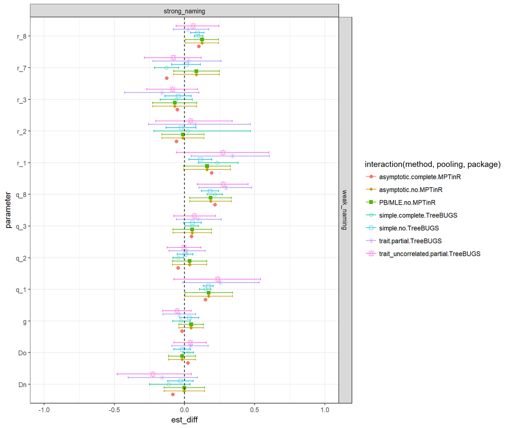

**Q restricted**

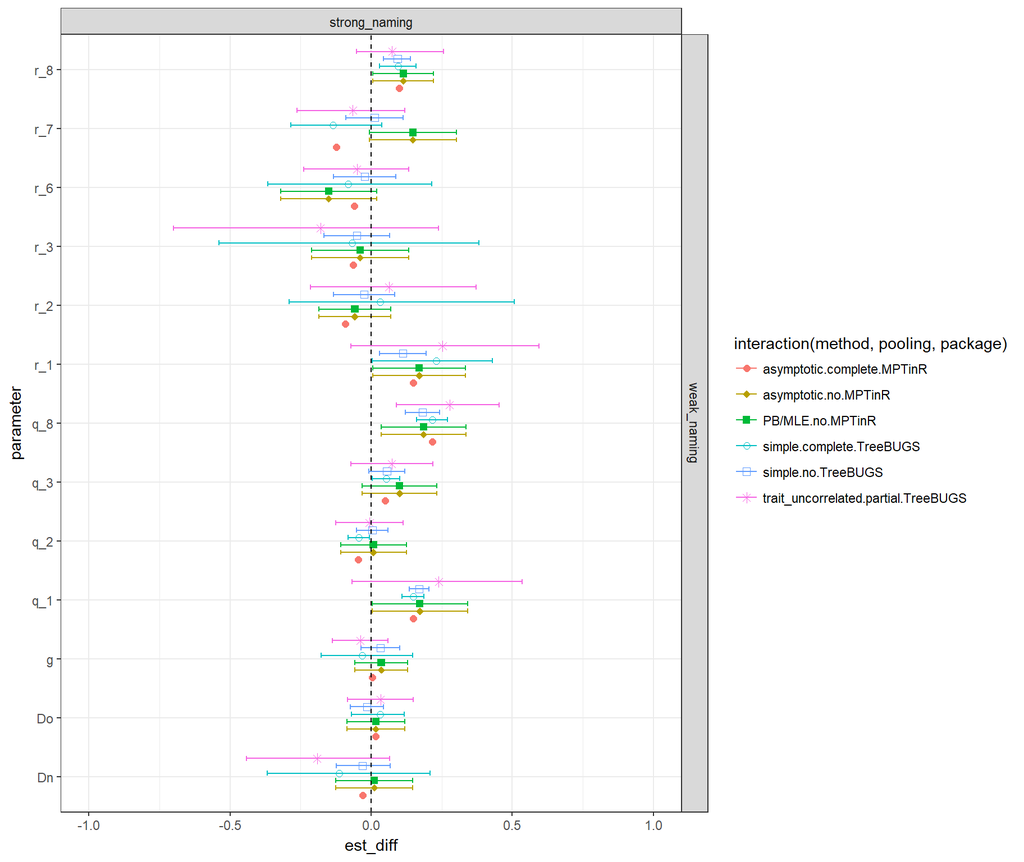

**R restricted**

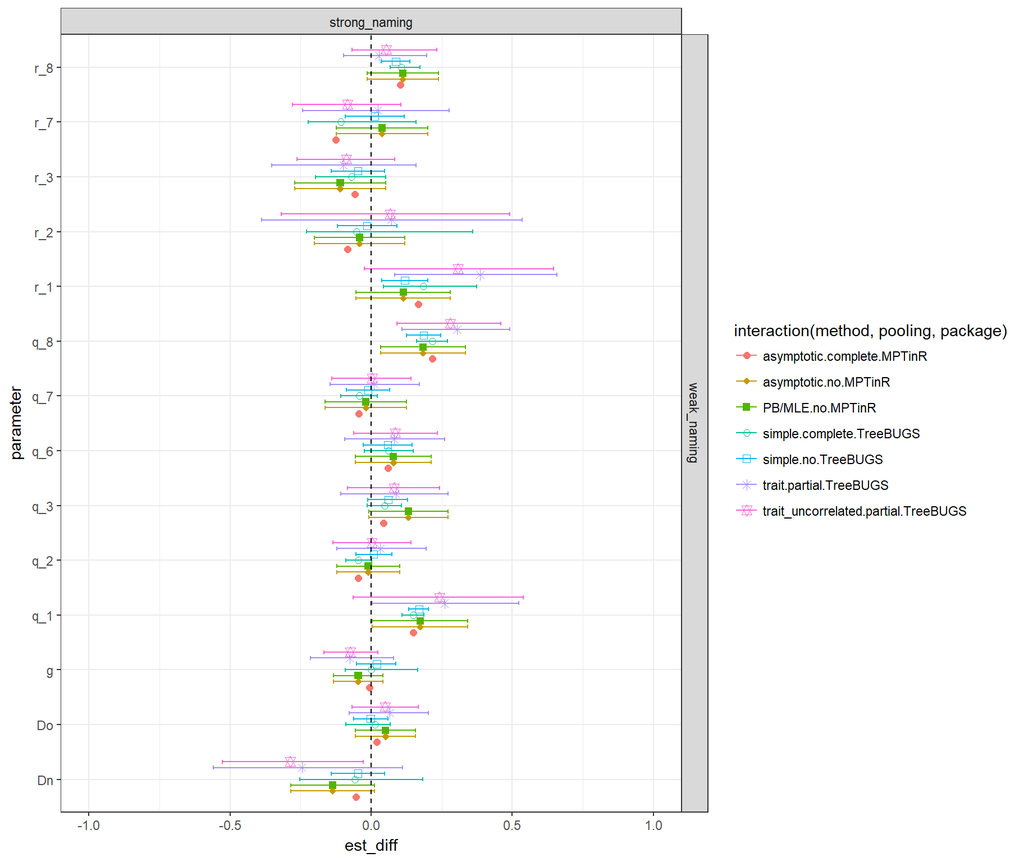

**Core parameters**

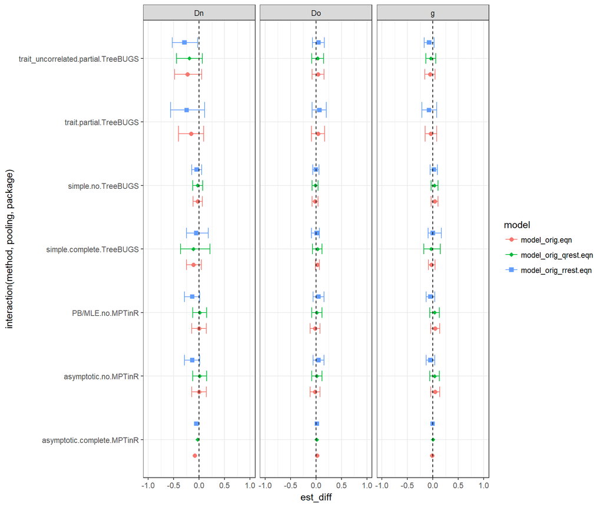

**Q Parameters**

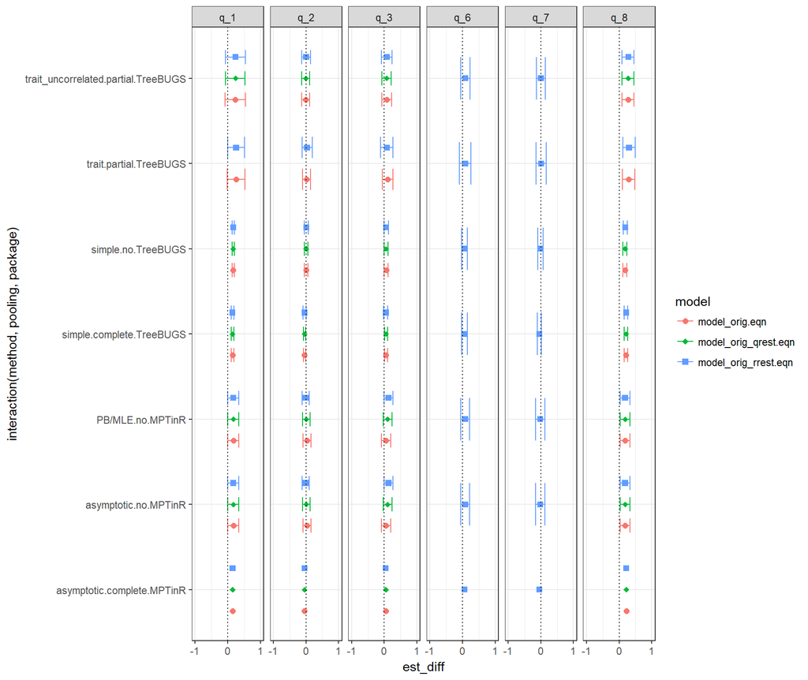

**R Parameters**

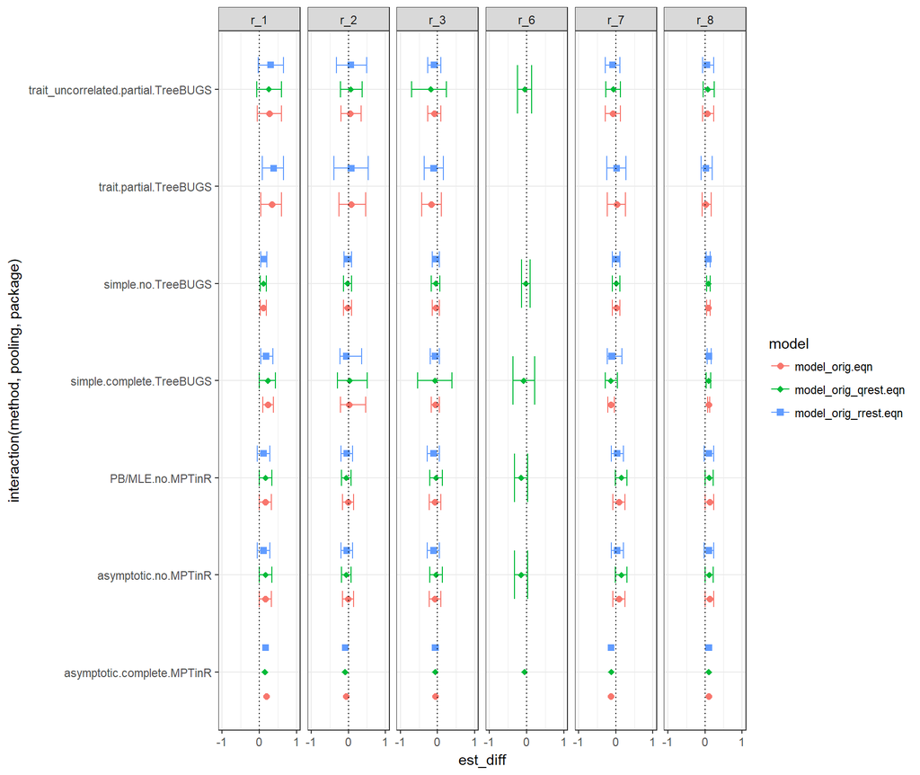

### Goodness of fit

**Model Original**

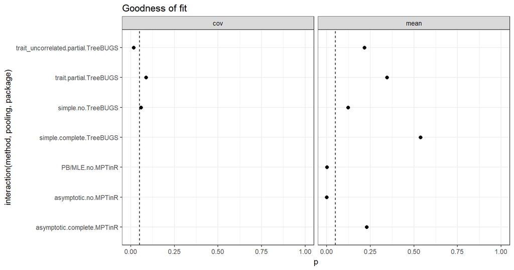

**Q restricted**

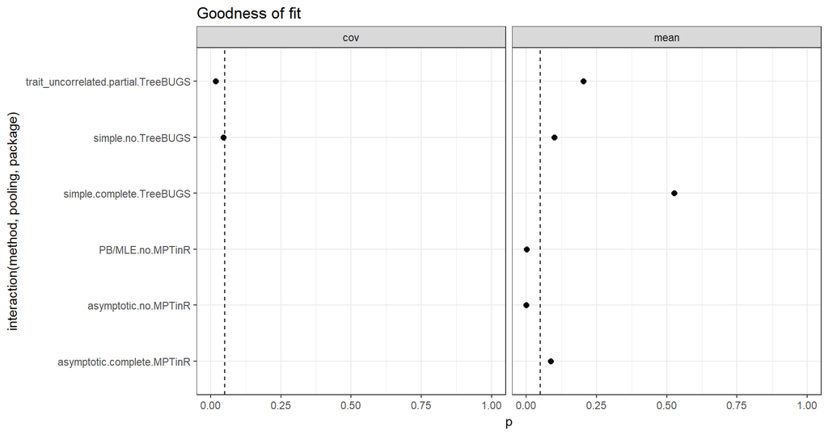

**R restricted**

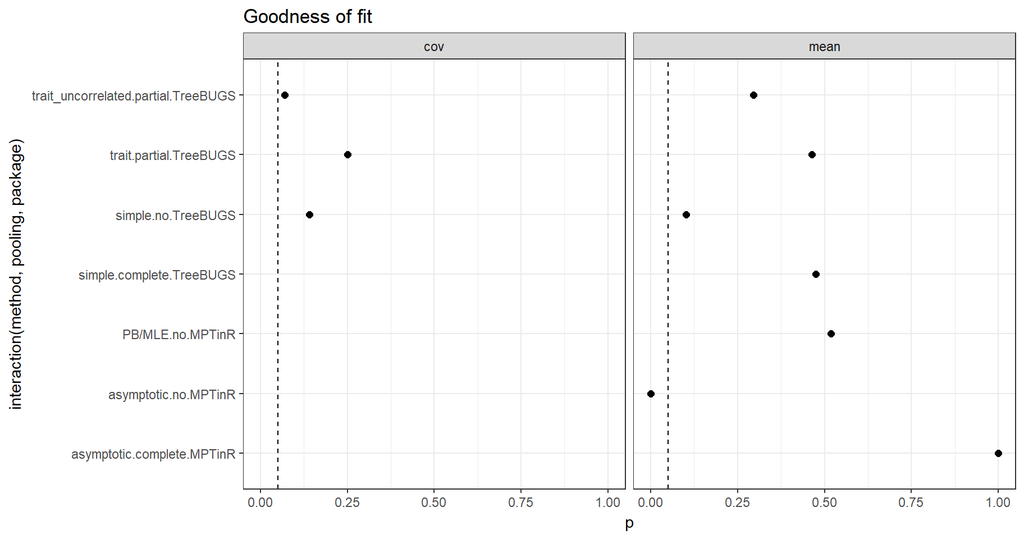

### Goodness of fit per condition

**Model Original**

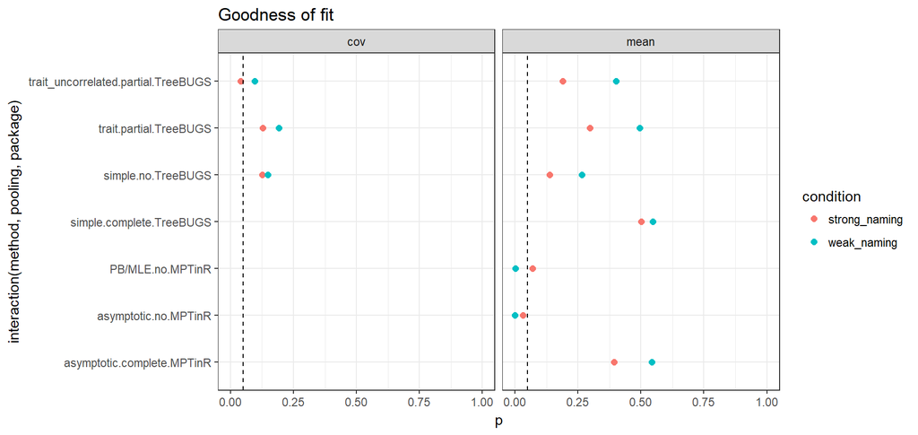

**Q restricted**

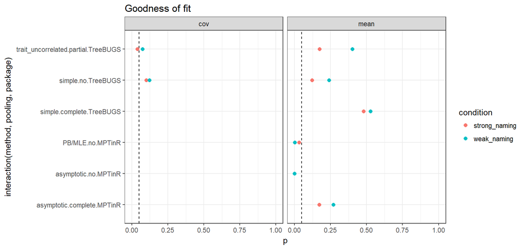

**R restricted**

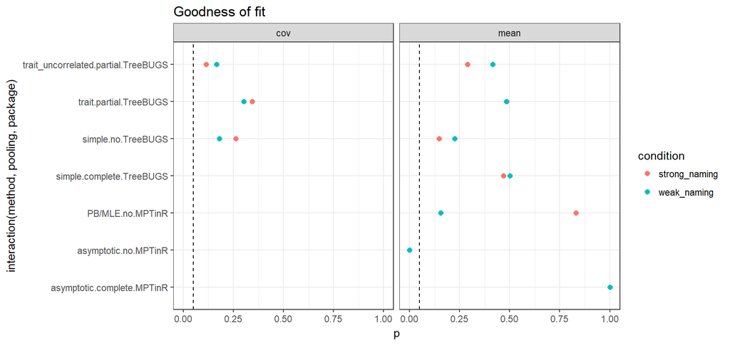